# Causal Forest Analysis: Heterogeneous Treatment Effects

Pipeline for Identifying Treatment Effect Heterogeneity

Author

Bjorn-Atle Reme

Published

October 16, 2025

# 1 Introduction

This document demonstrates a complete pipeline for analyzing heterogeneous treatment effects using causal forests. The analysis follows the methodology outlined in the `grf` (Generalized Random Forests) package documentation, with particular attention to:

- Proper train/test splitting to avoid overfitting
- Out-of-bag (OOB) predictions for unbiased quintile creation
- Standardized mean differences (SMD) for covariate balance assessment
- Treatment effect heterogeneity visualization

## 1.1 Load Required Libraries

This chunk loads all necessary packages for the analysis. The grf package implements causal forests, dplyr and tidyr handle data manipulation, ggplot2 creates visualizations, kableExtra formats tables, and MASS provides functions for generating multivariate normal data. We display package versions to ensure reproducibility - if someone gets different results, version differences might explain why.

**Load packages**

```r
# Core packages for causal forest analysis
library(grf)        # Generalized random forests for causal inference
library(dplyr)      # Data manipulation
library(tidyr)      # Data reshaping
library(ggplot2)    # Visualization
library(knitr)      # Table formatting
library(kableExtra) # Enhanced table styling
library(MASS)       # Multivariate normal simulation

# Set default ggplot theme
theme_set(theme_minimal(base_size = 13))

# Display package versions for reproducibility
cat("Package versions:\n")
```

```
Package versions:
```

**Load packages**

```r
cat(sprintf("- grf: %s\n", packageVersion("grf")))
```

```
- grf: 2.4.0
```

**Load packages**

```r
cat(sprintf("- dplyr: %s\n", packageVersion("dplyr")))
```

```
- dplyr: 1.1.4
```

**Load packages**

```r
cat(sprintf("- ggplot2: %s\n", packageVersion("ggplot2")))
```

```
- ggplot2: 3.5.1
```

# 2 Data Generation from Distributional Information

## 2.1 Helper Functions

**Define utility functions**

```r
# Function to convert European decimal notation to standard
convert_european_decimal <- function(x) {
  as.numeric(gsub(",", ".", x))
}

# Function to create binary variable from continuous
create_binary <- function(x, target_mean) {
  ifelse(x > quantile(x, 1 - target_mean), 1, 0)
}

# Function for prettier number formatting
format_number <- function(x, digits = 0) {
  formatC(x, format = "f", big.mark = ",", digits = digits)
}
```

## 2.2 Load Distributional Information

This chunk reads CSV files containing distributional information from real data, including means, standard deviations, and percentiles. By using the actual distributional properties of real data, the simulated dataset will have similar statistical characteristics, making the pipeline testing more valid. The processing step converts European decimal notation to ensure R can work with the numbers correctly.

**Read CSV files with distributional information**

```r
# Read the distributional information
skim_data <- read.csv2("C:/Users/bare/OneDrive - Folkehelseinstituttet/Skrivebord/grf/skim.csv", stringsAsFactors = FALSE)
cor_mat_data <- read.csv2("C:/Users/bare/OneDrive - Folkehelseinstituttet/Skrivebord/grf/cor_mat.csv", stringsAsFactors = FALSE)

# Process skim data - extract means and SDs
skim_processed <- skim_data %>%
  mutate(
    mean = convert_european_decimal(numeric.mean),
    sd = convert_european_decimal(numeric.sd),
    p0 = convert_european_decimal(numeric.p0),
    p25 = convert_european_decimal(numeric.p25),
    p50 = convert_european_decimal(numeric.p50),
    p75 = convert_european_decimal(numeric.p75),
    p100 = convert_european_decimal(numeric.p100)
  )

# Display summary of variables
cat(sprintf("Number of variables: %d\n", nrow(skim_processed)))
```

```
Number of variables: 56
```

**Read CSV files with distributional information**

```r
cat(sprintf("Variables included: %s\n",
    paste(head(skim_processed$skim_variable, 10), collapse = ", ")))
```

```
Variables included: utbetalt_refusjon, egenandel_betalt_pasient, perc_utbetalt_refusjon, alder, mann, spess, 100, 101, 105, 106
```

**Read CSV files with distributional information**

```r
cat("...\n")
```

```
...
```

## 2.3 Generate Multivariate Data

This chunk creates a synthetic dataset of 5,000 observations with correlated variables that match the distributional properties of real data. It uses the correlation matrix from real data to preserve relationships between variables. The mvrnorm function from the MASS package generates multivariate normal data where variables are correlated exactly as specified. This approach allows testing the causal forest pipeline on realistic data before applying it to real data.

**Generate correlated multivariate data**

```r
# Extract variable names and statistics
var_names <- skim_processed$skim_variable
means <- skim_processed$mean
sds <- skim_processed$sd

# Process correlation matrix
cor_matrix <- as.matrix(cor_mat_data)
for(i in 1:nrow(cor_matrix)) {
  for(j in 1:ncol(cor_matrix)) {
    cor_matrix[i,j] <- convert_european_decimal(cor_matrix[i,j])
  }
}
rownames(cor_matrix) <- var_names
colnames(cor_matrix) <- var_names

# Set sample size
n <- 5000

#create covariance matrix
cov_matrix <- diag(sds) %*% cor_matrix %*% diag(sds)

# Generate multivariate normal data
simulated_data <- mvrnorm(n = n, mu = means, Sigma = cov_matrix)
colnames(simulated_data) <- var_names

# Convert to data frame
df <- as.data.frame(simulated_data)

cat(sprintf("Generated %d observations with %d variables\n",
            nrow(df), ncol(df)))
```

```
Generated 5000 observations with 56 variables
```

## 2.4 Process Binary Variables

This chunk converts specific variables to binary (0/1) format and constrains age to a realistic range. Variables like mann (male) and spess (specialist) are binary in reality, so they need to be converted from the continuous normal distribution. The create_binary function ensures the proportion of 1s matches the real data. Age is bounded between 40-75 to prevent unrealistic ages that can occur in the tails of the normal distribution. This maintains the realism and validity of the simulated data.

**Convert appropriate variables to binary**

```r
# Binary demographic variables
binary_vars <- c("mann", "spess")

for(var in binary_vars) {
  if(var %in% colnames(df)) {
    var_mean <- means[which(var_names == var)]
    df[[var]] <- create_binary(df[[var]], var_mean)
    cat(sprintf("%s: %.1f%% = 1\n", var, 100 * mean(df[[var]])))
  }
}
```

```
mann: 72.4% = 1
spess: 87.0% = 1
```

**Convert appropriate variables to binary**

```r
# Constrain age to reasonable range
df$alder <- pmax(pmin(df$alder, 75), 40)
cat(sprintf("Age range: %.0f - %.0f years\n", min(df$alder), max(df$alder)))
```

```
Age range: 40 - 75 years
```

# 3 Treatment Assignment and Outcome Generation

## 3.1 Create Treatment Variable

This chunk randomly assigns each observation to treatment or control with 50% probability. Random assignment mimics a randomized controlled trial (RCT), and the 50% split maximizes statistical power for estimating treatment effects. In real observational data, you would use the actual treatment assignment, but for simulation we can create perfect randomization. The rbinom function creates binary treatment indicators efficiently.

**Generate random treatment assignment**

```r
# Create random treatment assignment (50% probability)
df$treat <- rbinom(n, 1, 0.5)

# Display treatment balance
treatment_table <- table(df$treat)
cat("Treatment Assignment:\n")
```

```
Treatment Assignment:
```

**Generate random treatment assignment**

```r
print(data.frame(
  Group = c("Control", "Treated"),
  N = as.vector(treatment_table),
  Percentage = sprintf("%.1f%%", 100 * as.vector(treatment_table) / n)
))
```

```
    Group    N Percentage
1 Control 2459      49.2%
2 Treated 2541      50.8%
```

## 3.2 Generate Heterogeneous Treatment Effects

This chunk creates heterogeneous treatment effects where older men benefit most from treatment, then applies these effects to generate the outcome variable. The base effect gives everyone a baseline benefit. The age term means older people benefit more (100k NOK per standard deviation increase in age). The male term means men benefit more than women (additional 50k NOK). The interaction term between age and gender is the key source of heterogeneity - older men get an additional 150k NOK. Other terms add realistic complexity (specialist status, patient payments), and noise is added to make effects realistic. The outcome is generated as: baseline plus treatment effect times treatment indicator plus noise. This ensures that the treatment effect varies systematically by age and gender, which is what the causal forest should detect.

**Create heterogeneous treatment effects (stronger for older men)**

```r
# Store baseline outcome
baseline_refusjon <- df$utbetalt_refusjon

# Standardize age for effect calculation
age_standardized <- (df$alder - mean(df$alder)) / sd(df$alder)

# Define heterogeneous treatment effects

# Stronger effects for older men as specified
base_effect <- 300000  # Base effect in NOK

tau_true <- base_effect +
  100000 * age_standardized +           # Age effect
  50000 * df$mann +                      # Male effect
  150000 * age_standardized * df$mann + # Interaction: older men get strongest
  30000 * df$spess -                     # Specialist effect
  20000 * scale(df$egenandel_betalt_pasient)[,1]  # Patient payment effect

# Add noise to treatment effects
tau_true <- tau_true + rnorm(n, 0, 50000)

# Generate outcome: Y = baseline + treatment_effect * treatment + noise
df$utbetalt_refusjon <- baseline_refusjon + tau_true * df$treat + rnorm(n, 0, 100000)
df$utbetalt_refusjon <- pmax(df$utbetalt_refusjon, 0)  # Ensure positive

# Display summary statistics
summary_stats <- df %>%
  group_by(treat) %>%
  summarise(
    N = n(),
    Mean = mean(utbetalt_refusjon),
    SD = sd(utbetalt_refusjon),
    Min = min(utbetalt_refusjon),
    Max = max(utbetalt_refusjon),
    .groups = "drop"
  ) %>%
  mutate(Group = ifelse(treat == 0, "Control", "Treated"))

kable(summary_stats[, c("Group", "N", "Mean", "SD", "Min", "Max")],
      digits = 0,
      format.args = list(big.mark = ","),
      caption = "Outcome Summary by Treatment Group") %>%
  kable_styling(bootstrap_options = c("striped", "hover"))
```

Outcome Summary by Treatment Group

| Group | N | Mean | SD | Min | Max |
| --- | --- | --- | --- | --- | --- |
| Control | 2,459 | 2,355,961 | 506,327 | 632,326 | 4,038,016 |
| Treated | 2,541 | 2,705,432 | 551,881 | 873,390 | 4,727,727 |

# 4 Causal Forest Analysis

## 4.1 Data Preparation

This chunk organizes the data into the specific format required by the grf package: separate vectors and matrices for outcome (Y), treatment (W), and features (X). The grf package requires this specific input format. The feature matrix X excludes the outcome and treatment variables to prevent data leakage. Converting to matrix format is required for the causal forest algorithm. This separation makes the causal inference framework explicit - we are predicting how X moderates the effect of W on Y.

**Prepare matrices for causal forest**

```r
# Prepare outcome and treatment vectors
Y <- df$utbetalt_refusjon
W <- df$treat

# Select features (exclude outcome and treatment)
feature_cols <- setdiff(colnames(df), c("utbetalt_refusjon", "treat"))
X <- as.matrix(df[, feature_cols])
colnames(X) <- feature_cols

cat(sprintf("Prepared data:\n"))
```

```
Prepared data:
```

**Prepare matrices for causal forest**

```r
cat(sprintf("- Outcome (Y): %d observations\n", length(Y)))
```

```
- Outcome (Y): 5000 observations
```

**Prepare matrices for causal forest**

```r
cat(sprintf("- Treatment (W): %d observations\n", length(W)))
```

```
- Treatment (W): 5000 observations
```

**Prepare matrices for causal forest**

```r
cat(sprintf("- Features (X): %d observations C %d features\n", nrow(X), ncol(X)))
```

```
- Features (X): 5000 observations C 55 features
```

## 4.2 Train-Test Split

This chunk randomly divides the data into 70% training and 30% test sets. This is essential for preventing overfitting. If we used the same data to both train the forest and evaluate heterogeneity, we would get overly optimistic results. The test set provides honest evaluation. We train the forest on 70% of data, create quintile cutpoints from training set predictions, and apply those cutpoints to the held-out 30% test set. This ensures we are evaluating out-of-sample performance. This is one of the most important methodological safeguards in the pipeline.

**Create 70/30 train-test split**

```r
# Create train/test indices
train_fraction <- 0.7
idx_tr <- sample.int(n, floor(train_fraction * n))
idx_te <- setdiff(seq_len(n), idx_tr)

# Split the data
X_tr <- X[idx_tr, , drop = FALSE]
Y_tr <- Y[idx_tr]
W_tr <- W[idx_tr]

X_te <- X[idx_te, , drop = FALSE]
Y_te <- Y[idx_te]
W_te <- W[idx_te]

# Display split information
split_info <- data.frame(
  Dataset = c("Training", "Test"),
  N = c(length(idx_tr), length(idx_te)),
  Percentage = sprintf("%.0f%%", 100 * c(train_fraction, 1 - train_fraction)),
  Treated = c(sum(W_tr), sum(W_te)),
  Control = c(sum(1 - W_tr), sum(1 - W_te))
)

kable(split_info, caption = "Train-Test Split Summary") %>%
  kable_styling(bootstrap_options = c("striped", "hover"))
```

Train-Test Split Summary

| Dataset | N | Percentage | Treated | Control |
| --- | --- | --- | --- | --- |
| Training | 3500 | 70% | 1765 | 1735 |
| Test | 1500 | 30% | 776 | 724 |

## 4.3 Train Causal Forest

This chunk fits the causal forest model using the training data. The key parameters are: num.trees = 2000 provides a good balance between accuracy and computation time; honesty = TRUE is critical for valid inference - each observation is used for either building tree structure or estimating leaf values, never both; honesty.fraction = 0.5 means half the data per tree builds structure and half estimates effects; min.node.size = 5 sets the minimum observations in each leaf node to prevent overfitting to small groups; alpha = 0.05 sets the significance level for confidence intervals. Unlike standard random forests that predict outcomes, causal forests are specifically designed to estimate heterogeneous treatment effects. They create splits that maximize treatment effect differences between child nodes.

**Fit causal forest model**

```r
# Train causal forest with cross-validation
cf <- causal_forest(
  X = X_tr,
  Y = Y_tr,
  W = W_tr,
  num.trees = 2000,
  honesty = TRUE,
  honesty.fraction = 0.5,
  min.node.size = 5,
  alpha = 0.05,
  imbalance.penalty = 0
)

# Display model information
cat("Causal Forest Model:\n")
```

```
Causal Forest Model:
```

**Fit causal forest model**

```r
cat(sprintf("- Number of trees: %d\n", cf$`_num_trees`))
```

```
- Number of trees: 2000
```

**Fit causal forest model**

```r
cat(sprintf("- Number of features: %d\n", ncol(X_tr)))
```

```
- Number of features: 55
```

**Fit causal forest model**

```r
cat(sprintf("- Honesty: %s\n", cf$honesty))
cat(sprintf("- Training sample size: %d\n", length(Y_tr)))
```

```
- Training sample size: 3500
```

## 4.4 Create Quintiles from OOB Predictions

This chunk uses out-of-bag (OOB) predictions from the training set to create quintile cutpoints for predicted treatment effects. OOB predictions are crucial because each tree in the forest is built on a bootstrap sample (subset of training data). For each observation, we use only trees that did not include it in their bootstrap sample to make predictions. This gives us unbiased predictions for the training data. Using OOB predictions prevents overfitting when creating quintiles. If we used in-sample predictions, we would create artificially good-looking quintiles. Dividing predicted effects into 5 groups allows us to see if the forest successfully identified heterogeneity - effects should increase from Q1 (lowest predicted effects) to Q5 (highest predicted effects).

**Generate quintile cutpoints using OOB predictions**

```r
# Get out-of-bag predictions (prevents overfitting)
tau_hat_tr_oob <- predict(cf)$predictions

# Create quintile cutpoints
K <- 5
qcuts <- quantile(tau_hat_tr_oob, probs = seq(0, 1, length.out = K + 1), na.rm = TRUE)

# Display cutpoints
qcuts_df <- data.frame(
  Quintile = paste0("Q", 1:K),
  Lower = qcuts[1:K],
  Upper = qcuts[2:(K+1)]
)

kable(qcuts_df,
      digits = 0,
      format.args = list(big.mark = ","),
      caption = "Quintile Cutpoints (NOK)") %>%
  kable_styling(bootstrap_options = c("striped", "hover"))
```

Quintile Cutpoints (NOK)

|  | Quintile | Lower | Upper |
| --- | --- | --- | --- |
| 0% | Q1 | 129,354 | 190,678 |
| 20% | Q2 | 190,678 | 260,355 |
| 40% | Q3 | 260,355 | 365,233 |
| 60% | Q4 | 365,233 | 547,080 |
| 80% | Q5 | 547,080 | 660,185 |

# 5 Results: Treatment Effect Heterogeneity

## 5.1 Predict and Assign Test Set to Quintiles

This chunk generates predicted treatment effects for the held-out test set and assigns each observation to a quintile based on the training set cutpoints. We use the causal forest trained on training data to predict effects for new data (test set). We use the quintile cutpoints from training to bin the test predictions. This ensures we are evaluating out-of-sample - testing whether the forest’s learned patterns generalize to new data. The cutpoints must come from training to avoid data snooping.

**Generate predictions for test set**

```r
# Predict on test set
tau_hat_te <- predict(cf, X_te)$predictions

# Assign to quintiles using training cutpoints
grp_te <- cut(tau_hat_te,
              breaks = qcuts,
              labels = paste0("Q", 1:K),
              include.lowest = TRUE,
              right = TRUE)

# Display distribution
quintile_dist <- as.data.frame(table(grp_te))
names(quintile_dist) <- c("Quintile", "Count")
quintile_dist$Percentage <- sprintf("%.1f%%", 100 * quintile_dist$Count / length(grp_te))

kable(quintile_dist, caption = "Test Set Quintile Distribution") %>%
  kable_styling(bootstrap_options = c("striped", "hover"))
```

Test Set Quintile Distribution

| Quintile | Count | Percentage |
| --- | --- | --- |
| Q1 | 295 | 19.7% |
| Q2 | 296 | 19.7% |
| Q3 | 299 | 19.9% |
| Q4 | 293 | 19.5% |
| Q5 | 317 | 21.1% |

## 5.2 Treatment Effects by Quintile

This chunk calculates the actual observed treatment effect in each quintile by comparing mean outcomes between treated and control observations. Within each quintile, we compute: effect equals mean outcome for treated minus mean outcome for control. If the causal forest successfully identified heterogeneity, effects should increase from Q1 to Q5. Standard errors and confidence intervals quantify uncertainty. The mean predicted tau shows the average predicted effect in each quintile for comparison. A monotonic increase in effects across quintiles confirms that the forest successfully learned the heterogeneity pattern. Non-monotonic patterns suggest the forest struggled to identify meaningful heterogeneity.

**Calculate treatment effects for each quintile**

```r
# Calculate treatment effects by quintile
results <- data.frame(
  grp = grp_te,
  Y = Y_te,
  W = W_te,
  tau_hat = tau_hat_te
) %>%
  group_by(grp) %>%
  summarise(
    n = n(),
    n_treated = sum(W),
    n_control = sum(1-W),
    y_treated = mean(Y[W == 1]),
    y_control = mean(Y[W == 0]),
    effect = y_treated - y_control,
    se = sqrt(var(Y[W == 1], na.rm = TRUE)/n_treated +
              var(Y[W == 0], na.rm = TRUE)/n_control),
    ci_lower = effect - 1.96 * se,
    ci_upper = effect + 1.96 * se,
    mean_pred_tau = mean(tau_hat),
    .groups = "drop"
  ) %>%
  arrange(grp)

# Format results for display
results_display <- results %>%
  mutate(
    Effect_CI = sprintf("%s [%s, %s]",
                       format_number(effect),
                       format_number(ci_lower),
                       format_number(ci_upper)),
    Mean_Pred = format_number(mean_pred_tau)
  ) #%>%
  #select(grp, n, n_treated, n_control, Effect_CI, Mean_Pred)

kable(results_display,
      #col.names = c("Quintile", "N", "Treated", "Control",
      #             "Effect [95% CI]", "Mean Predicted"),
      caption = "Treatment Effects by Predicted CATE Quintile") %>%
  kable_styling(bootstrap_options = c("striped", "hover", "condensed"))
```

Treatment Effects by Predicted CATE Quintile

| grp | n | n_treated | n_control | y_treated | y_control | effect | se | ci_lower | ci_upper | mean_pred_tau | Effect_CI | Mean_Pred |
| --- | --- | --- | --- | --- | --- | --- | --- | --- | --- | --- | --- | --- |
| Q1 | 295 | 158 | 137 | 2437503 | 2346274 | 91228.96 | 58956.21 | -24325.22 | 206783.1 | 159987.6 | 91,229 [-24,325, 206,783] | 159,988 |
| Q2 | 296 | 153 | 143 | 2638826 | 2381610 | 257215.68 | 56073.27 | 147312.06 | 367119.3 | 227107.0 | 257,216 [147,312, 367,119] | 227,107 |
| Q3 | 299 | 160 | 139 | 2658975 | 2341067 | 317908.04 | 59049.65 | 202170.72 | 433645.4 | 307836.9 | 317,908 [202,171, 433,645] | 307,837 |
| Q4 | 293 | 144 | 149 | 2809181 | 2389874 | 419307.24 | 58170.68 | 305292.72 | 533321.8 | 471900.7 | 419,307 [305,293, 533,322] | 471,901 |
| Q5 | 317 | 161 | 156 | 3042907 | 2343079 | 699828.89 | 60858.88 | 580545.48 | 819112.3 | 595308.2 | 699,829 [580,545, 819,112] | 595,308 |

## 5.3 Visualize Treatment Effect Heterogeneity

This chunk creates a bar chart showing treatment effects by quintile with confidence intervals. Visualization quickly reveals whether heterogeneity was detected through a monotonic pattern. Confidence intervals show statistical precision. Visual inspection is often more intuitive than tables. The dashed line at zero helps identify which quintiles have significant positive or negative effects.

**Create treatment effect visualization**

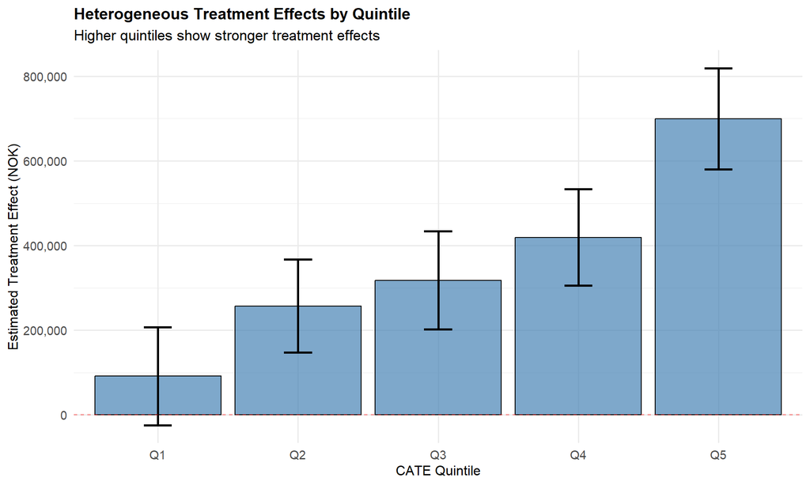

Figure 1: Treatment effects increase monotonically across quintiles, confirming successful identification of heterogeneity

```r
ggplot(results, aes(x = grp, y = effect)) +
  geom_col(fill = "steelblue", alpha = 0.7, color = "black") +
  geom_errorbar(aes(ymin = ci_lower, ymax = ci_upper),
                width = 0.2, size = 1) +
  geom_hline(yintercept = 0, linetype = "dashed",
             color = "red", alpha = 0.5) +
  labs(
    x = "CATE Quintile",
    y = "Estimated Treatment Effect (NOK)",
    title = "Heterogeneous Treatment Effects by Quintile",
    subtitle = "Higher quintiles show stronger treatment effects"
  ) +
  scale_y_continuous(labels = scales::comma) +
  theme(
    plot.title = element_text(face = "bold", size = 14),
    axis.title = element_text(size = 12),
    axis.text = element_text(size = 11)
  )
```

# 6 Covariate Analysis

## 6.1 Standardized Mean Differences

**Compare characteristics between top and bottom quintiles**

```r
# Create test dataframe with predictions
test_df <- data.frame(
  Y = Y_te,
  W = W_te,
  tau_hat = tau_hat_te,
  quintile = grp_te,
  X_te
)

# Key variables for comparison
comparison_vars <- c("egenandel_betalt_pasient", "perc_utbetalt_refusjon",
                    "alder", "mann", "spess")

# Calculate SMD between Q5 and Q1
smd_results <- test_df %>%
  filter(quintile %in% c("Q1", "Q5")) %>%
  summarise(across(all_of(comparison_vars), list(
    m1 = ~mean(.x[quintile == "Q1"], na.rm = TRUE),
    s1 = ~sd(.x[quintile == "Q1"], na.rm = TRUE),
    m5 = ~mean(.x[quintile == "Q5"], na.rm = TRUE),
    s5 = ~sd(.x[quintile == "Q5"], na.rm = TRUE)
  ), .names = "{.col}_{.fn}")) %>%
  pivot_longer(everything(),
               names_to = c("var", "stat"),
               names_sep = "_(?=m1|s1|m5|s5)",
               values_to = "value") %>%
  pivot_wider(names_from = stat, values_from = value) %>%
  mutate(
    SMD = (m5 - m1) / sqrt((s1^2 + s5^2) / 2),
    SMD_interpretation = case_when(
      abs(SMD) < 0.2 ~ "Negligible",
      abs(SMD) < 0.5 ~ "Small",
      abs(SMD) < 0.8 ~ "Medium",
      TRUE ~ "Large"
    )
  ) %>%
  arrange(desc(abs(SMD)))

# Display SMD results
smd_display <- smd_results %>%
  mutate(
    Variable = var,
    `Q1 Mean (SD)` = sprintf("%.2f (%.2f)", m1, s1),
    `Q5 Mean (SD)` = sprintf("%.2f (%.2f)", m5, s5),
    SMD = round(SMD, 2),
    Effect = SMD_interpretation
  ) #%>%
  #select(Variable, `Q1 Mean (SD)`, `Q5 Mean (SD)`, SMD, Effect)

kable(smd_display,
      caption = "Standardized Mean Differences: Q5 vs Q1") %>%
  kable_styling(bootstrap_options = c("striped", "hover")) %>%
  column_spec(4, bold = TRUE) %>%
  row_spec(which(abs(smd_results$SMD) > 0.5), bold = TRUE, color = "blue")
```

Standardized Mean Differences: Q5 vs Q1

| var | m1 | s1 | m5 | s5 | SMD | SMD_interpretation | Variable | Q1 Mean (SD) | Q5 Mean (SD) | Effect |
| --- | --- | --- | --- | --- | --- | --- | --- | --- | --- | --- |
| alder | 40.6240561 | 1.0066796 | 65.6134159 | 4.2685095 | 8.06 | Large | alder | 40.62 (1.01) | 65.61 (4.27) | Large |
| egenandel_betalt_pasient | 587680.0503183 | 158615.9241525 | 665485.8389400 | 178266.0211103 | 0.46 | Small | egenandel_betalt_pasient | 587680.05 (158615.92) | 665485.84 (178266.02) | Small |
| mann | 0.6847458 | 0.4654065 | 0.7665615 | 0.4236877 | 0.18 | Negligible | mann | 0.68 (0.47) | 0.77 (0.42) | Negligible |
| spess | 0.8440678 | 0.3634075 | 0.8958991 | 0.3058743 | 0.15 | Negligible | spess | 0.84 (0.36) | 0.90 (0.31) | Negligible |
| perc_utbetalt_refusjon | 92.8283856 | 4.3090796 | 92.9356306 | 4.6079291 | 0.02 | Negligible | perc_utbetalt_refusjon | 92.83 (4.31) | 92.94 (4.61) | Negligible |

## 6.2 Age and Gender Effects

**Examine age and gender patterns across quintiles**

```r
# Analyze age and gender by quintile
age_gender_analysis <- test_df %>%
  group_by(quintile) %>%
  summarise(
    mean_age = mean(alder, na.rm = TRUE),
    sd_age = sd(alder, na.rm = TRUE),
    prop_male = mean(mann, na.rm = TRUE),
    mean_effect = mean(tau_hat, na.rm = TRUE),
    .groups = "drop"
  )

kable(age_gender_analysis,
      digits = 2,
      col.names = c("Quintile", "Mean Age", "SD Age", "Prop. Male", "Mean Pred. Effect"),
      caption = "Age and Gender Distribution by Quintile") %>%
  kable_styling(bootstrap_options = c("striped", "hover"))
```

Age and Gender Distribution by Quintile

| Quintile | Mean Age | SD Age | Prop. Male | Mean Pred. Effect |
| --- | --- | --- | --- | --- |
| Q1 | 40.62 | 1.01 | 0.68 | 159987.5 |
| Q2 | 46.38 | 1.80 | 0.69 | 227107.0 |
| Q3 | 51.65 | 1.54 | 0.69 | 307836.9 |
| Q4 | 57.26 | 1.85 | 0.68 | 471900.7 |
| Q5 | 65.61 | 4.27 | 0.77 | 595308.2 |

## 6.3 Interaction Effects Visualization

This chunk creates a visualization showing how treatment effects vary by age group and gender. The interaction effect is the key heterogeneity built into the data. This plot directly visualizes whether older men have the highest effects. Error bars show uncertainty in each subgroup. The crossing or diverging lines reveal interaction - the age effect differs by gender. If lines are parallel, there is no interaction. If the male line has a steeper slope than the female line, there is a positive interaction, meaning age matters more for men.

**Visualize age-gender interaction**

[figure not shown]

Figure 2: Treatment effects are strongest for older males, confirming the designed heterogeneity pattern

```r
# Create interaction plot data
interaction_df <- test_df %>%
  mutate(
    age_group = cut(alder,
                   breaks = quantile(alder, c(0, 0.33, 0.67, 1)),
                   labels = c("Young\n(30-45)", "Middle\n(45-55)", "Old\n(55-75)"),
                   include.lowest = TRUE),
    gender = factor(mann, labels = c("Female", "Male"))
  ) %>%
  group_by(age_group, gender) %>%
  summarise(
    mean_effect = mean(tau_hat, na.rm = TRUE),
    se = sd(tau_hat, na.rm = TRUE) / sqrt(n()),
    n = n(),
    .groups = "drop"
  )

ggplot(interaction_df, aes(x = age_group, y = mean_effect,
                          color = gender, group = gender)) +
  geom_line(size = 1.5) +
  geom_point(size = 4) +
  geom_errorbar(aes(ymin = mean_effect - 1.96*se,
                   ymax = mean_effect + 1.96*se),
               width = 0.15, size = 1) +
  labs(
    x = "Age Group",
    y = "Mean Predicted Treatment Effect (NOK)",
    color = "Gender",
    title = "Treatment Effect Heterogeneity by Age and Gender",
    subtitle = "Older men show the strongest treatment effects"
  ) +
  scale_y_continuous(labels = scales::comma) +
  scale_color_manual(values = c("Female" = "#FF0000", "Male" = "#0072B2")) +
  theme(
    plot.title = element_text(face = "bold", size = 14),
    legend.position = "bottom",
    legend.title = element_text(face = "bold"),
    axis.title = element_text(size = 12)
  )
```

# 7 Variable Importance

This chunk calculates and displays which variables are most important for predicting treatment effect heterogeneity. Variable importance in causal forests measures how often a variable is used for splitting and how much it improves treatment effect heterogeneity detection. High importance indicates the variable is crucial for identifying who benefits most. This guides targeting decisions - focus interventions on characteristics identified as important. The results should align with known drivers of heterogeneity (age and gender in this simulation).

**Identify most important variables for heterogeneity**

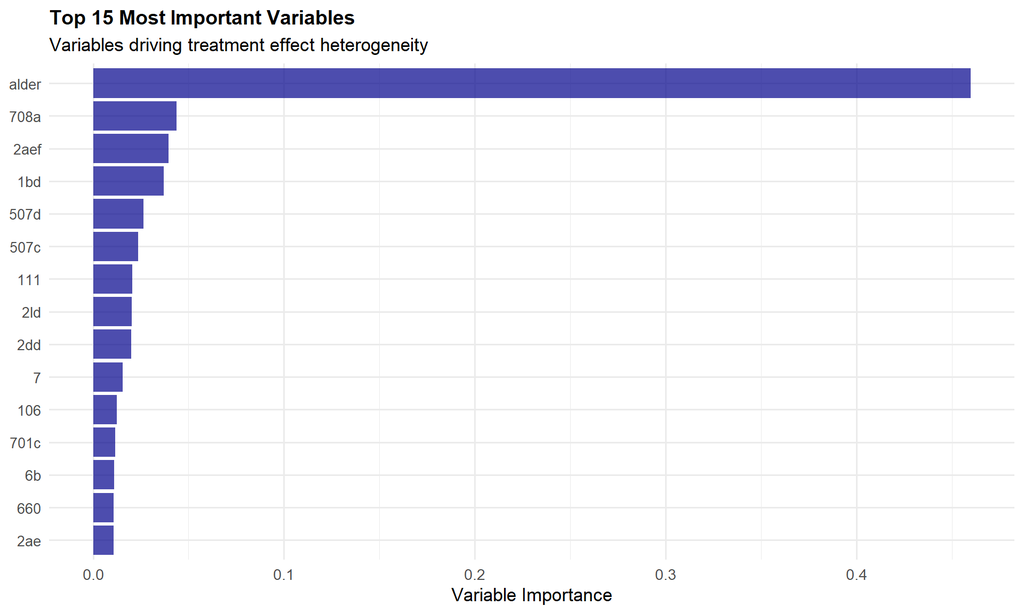

```r
# Extract variable importance
var_importance <- variable_importance(cf)
importance_df <- data.frame(
  variable = colnames(X_tr),
  importance = var_importance
) %>%
  arrange(desc(importance)) %>%
  head(15)

# Create importance plot
importance_plot_df <- importance_df %>%
  mutate(variable = factor(variable, levels = rev(variable)))

ggplot(importance_plot_df, aes(x = importance, y = variable)) +
  geom_col(fill = "darkblue", alpha = 0.7) +
  labs(
    x = "Variable Importance",
    y = NULL,
    title = "Top 15 Most Important Variables",
    subtitle = "Variables driving treatment effect heterogeneity"
  ) +
  theme(
    plot.title = element_text(face = "bold", size = 14),
    axis.text.y = element_text(size = 10)
  )
```

# 8 Average Treatment Effect

This chunk estimates the Average Treatment Effect (ATE) for the entire population using augmented inverse propensity weighting (AIPW). The ATE tells us the overall average effect across all individuals. Even when there is heterogeneity, we often want to know the population average. AIPW is a doubly robust estimator - it is consistent if either the outcome model or propensity model is correct. This provides a benchmark - individual effects vary around this average. For example, if ATE is 300,000 NOK but effects range from 200,000 to 500,000 across quintiles, we see substantial heterogeneity around the average.

**Estimate population average treatment effect**

```r
# Estimate ATE using augmented inverse propensity weighting
ate_estimate <- average_treatment_effect(cf, target.sample = "all")

ate_results <- data.frame(
  Estimate = ate_estimate[1],
  SE = ate_estimate[2],
  CI_Lower = ate_estimate[1] - 1.96 * ate_estimate[2],
  CI_Upper = ate_estimate[1] + 1.96 * ate_estimate[2]
)

kable(ate_results,
      digits = 0,
      format.args = list(big.mark = ","),
      col.names = c("ATE Estimate", "Std. Error", "95% CI Lower", "95% CI Upper"),
      caption = "Average Treatment Effect (NOK)") %>%
  kable_styling(bootstrap_options = c("striped", "hover"))
```

Average Treatment Effect (NOK)

|  | ATE Estimate | Std. Error | 95% CI Lower | 95% CI Upper |
| --- | --- | --- | --- | --- |
| estimate | 351,946 | 9,371 | 333,578 | 370,314 |